# rodion_hw2

Rodion

31 марта 2017 г

```r
library(DESeq2)
library(ggplot2)
library(pheatmap)
library(amap)
library(dbscan)
options(width=120)
```

# Задание 1: иерархическая кластеризация

Используем иерархическую клатеризацию для обнаружения аутлаера

Возьмем весь датасет с аутлаером

```r
counts <- read.csv("GSE89225_Illumina_counts.csv", row.names=1)
conditions <- read.csv("conditions.csv", row.names=1)
mart <- read.table("human_mart.txt", sep="\t", header=1, check.names = F)
print(counts[1:6, 1:2])
```

```
##                 tconv_tumor_patient10 cd177negtreg_tumor_patient10
## ENSG00000000003                   510                          935
## ENSG00000000005                    25                            1
## ENSG00000000419                   613                          818
## ENSG00000000457                   269                          587
## ENSG00000000460                    55                          142
## ENSG00000000938                    36                           69
```

```r
dim(counts)
```

```
## [1] 63677    34
```

```r
head(conditions)
```

```
##                                            tissue                               cells
## tconv_tumor_patient10        tissue: breast tumor cell type: Conventional CD4 T cells
## cd177negtreg_tumor_patient10 tissue: breast tumor       cell type: Regulatory T cells
## cd177postreg_tumor_patient10 tissue: breast tumor       cell type: Regulatory T cells
## tconv_tumor_patient1         tissue: breast tumor cell type: Conventional CD4 T cells
## treg_tumor_patient1          tissue: breast tumor       cell type: Regulatory T cells
## tconv_NBP_patient2                    tissue: NBP cell type: Conventional CD4 T cells
```

```r
dim(conditions)
```

```
## [1] 34  2
```

```r
head(mart)
```

```
##           Gene ID Associated Gene Name Gene type EntrezGene ID
## 1 ENSG00000252303            RNU6-280P     snRNA            NA
## 2 ENSG00000281771                Y_RNA  misc_RNA            NA
## 3 ENSG00000281256         RP11-222G7.2   lincRNA            NA
## 4 ENSG00000283272      Clostridiales-1      sRNA            NA
## 5 ENSG00000280864        RP11-654C22.2   lincRNA            NA
## 6 ENSG00000280792        RP11-315F22.1   lincRNA            NA
```

```r
dim(mart)
```

```
## [1] 64101     4
```

Создадим DeseqDataSet объект (дизайн не важен). Оставим только 8000 экспрессированых генов

```r
dds <- DESeqDataSetFromMatrix(countData = counts,
                              colData = conditions,
                              design = ~ tissue + cells)
ind <- order(rowSums(counts(dds)), decreasing = TRUE)
dds <- dds[ind, ][1:8000,]
dds <- DESeq(dds)
```

Используем rlog(dds) для получения логарифмированных значений экспрессии

```r
rlog_dds <- rlog(dds)
counts.log  <- assay(rlog_dds)
```

Посчитаем корреляции между образцами используя cor (результатом будет матрица размера m×mm×m, где m – количество образцов)

```r
rlog_dds_cor <- cor(counts.log)
```

Посчитаем матрицу “непохожести” 1 - cor, и dist объект для этой матрицы

```r
dissimilarity_rlog_dds_cor <- 1 - rlog_dds_cor
dist_dissimilarity_rlog_dds_cor <- dist(dissimilarity_rlog_dds_cor)
```

Сделаем кластеризацию с помощью функции hclust, используя три разных метода “связывания” объектов в группы: average, complete and single

```r
av_clust <- hclust(dist_dissimilarity_rlog_dds_cor, "average")
compl_clust <- hclust(dist_dissimilarity_rlog_dds_cor, "complete")
sing_clust <- hclust(dist_dissimilarity_rlog_dds_cor, "single")
```

Построим для каждой график с помощью plot

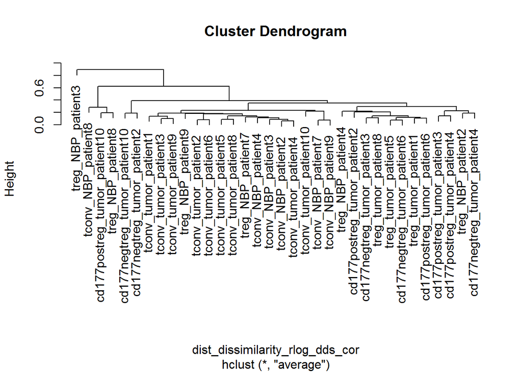

```r
plot(av_clust)
```

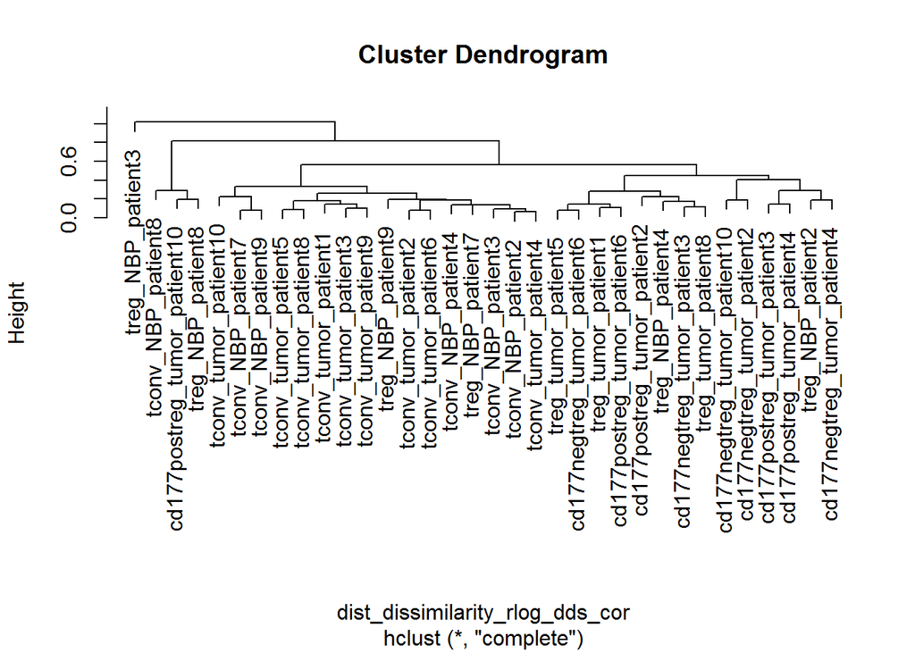

```r
plot(compl_clust)
```

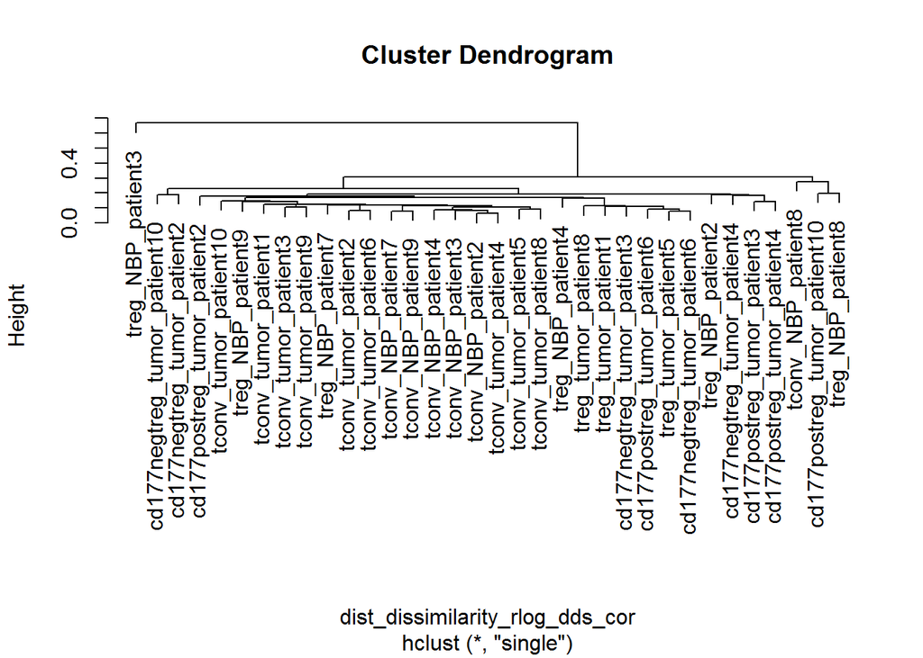

```r
plot(sing_clust)
```

```r
#замечен выброс: treg_NBP_patient3
```

# Задание 2: K-means

Используем K-means для описания паттернов экспрессии

Возьмем весь датасет без аутлаера

```r
counts2 <- read.csv("GSE89225_Illumina_counts.csv", row.names=1)
conditions2 <- read.csv("conditions.csv", row.names=1)

#Removing outlier
# При помощи Cluster Dendrogram и иерархической кластеризации было определно, что выбросом является образец treg_NBP_patient3
counts2$treg_NBP_patient3 <- NULL
#which(rownames(conditions2) == "treg_NBP_patient3")
conditions2 <- conditions2[-12, ]
# Выброс удален
```

Создадим DeseqDataSet объект (дизайн не важен). Оставим только 8000 экспрессированных генов

```r
dds2 <- DESeqDataSetFromMatrix(countData = counts2,
                              colData = conditions2,
                              design = ~ tissue + cells)
ind2 <- order(rowSums(counts(dds2)), decreasing = TRUE)
dds2 <- dds2[ind2, ][1:8000,]
dds2 <- DESeq(dds2)
```

Используем rlog(dds) для получения логарифмированных значений экспрессии

```r
rlog_dds2 <- rlog(dds2)
counts.log2  <- assay(rlog_dds2)
```

Используем функцию Kmeans из пакета amap с методом “correlation”, c количеством кластеров равным 6. (Вы можете выбрать своё количество кластеров), и максимальным количеством итераций равным 20000

```r
clustering <- Kmeans(counts.log2, 6, method="correlation", iter.max=20000)
```

После этого вы можете достать соотвествие каждого гена кластеру с помощью элемента листа с названием “cluster”

```r
head(clustering$cluster)
```

```
## ENSG00000166710 ENSG00000210082 ENSG00000251562 ENSG00000075624 ENSG00000198804 ENSG00000198938
##               5               2               6               5               3               3
```

После этого от вас потребуется эту кластеризацию изобразить на хитмапе: гены должны быть отсортированы по кластерам, а столбцы сначала по клеткам, а затем по тканям.

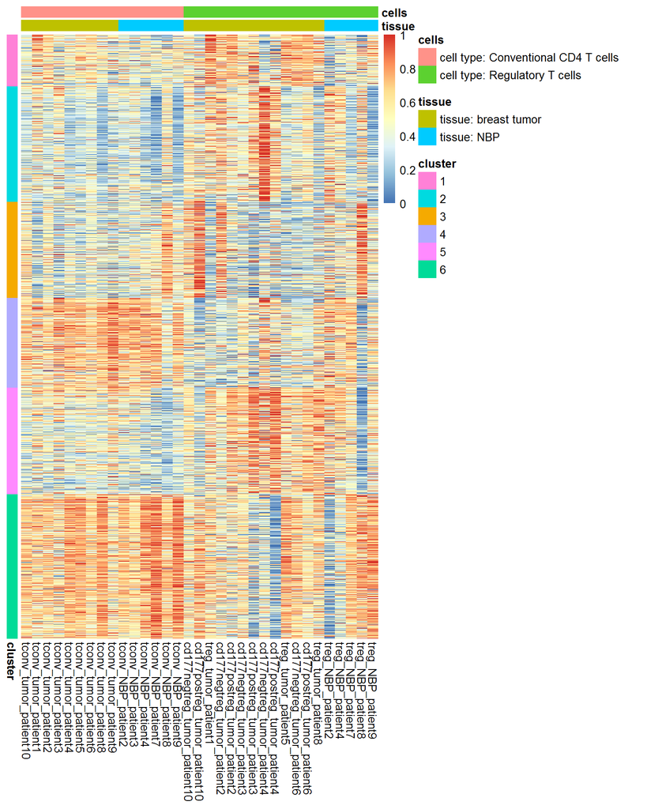

```r
to_visualise <- counts.log2[order(clustering$cluster), order(conditions2$cells, conditions2$tissue)]
cluster <- as.factor(clustering$cluster)
cluster <- as.data.frame(cluster)
to_visualise <- t(apply(to_visualise, 1, function(r) {
  (r - min(r)) / (max(r) - min(r))
}))


pheatmap(to_visualise,
         show_rownames = F, cluster_rows = F,
         cluster_cols=F,
         annotation_col = conditions,
         annotation_row =  cluster)
```

```r
# dev.off()
```

# Задание 3: Density based algortihms

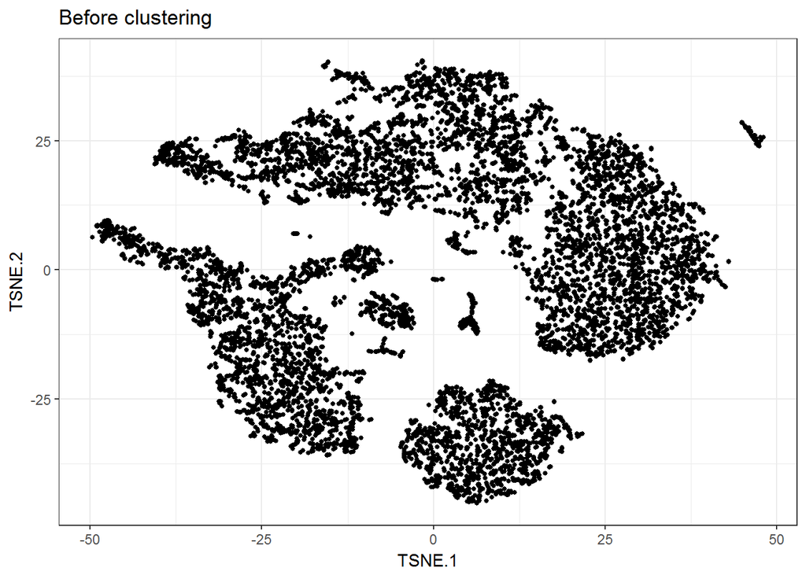

```r
rna_experiment <- read.csv("projection.csv")

ggplot(rna_experiment, aes(TSNE.1, TSNE.2)) +
  ggtitle("Before clustering") +
  geom_point(size = 1) +
  theme_bw()
```

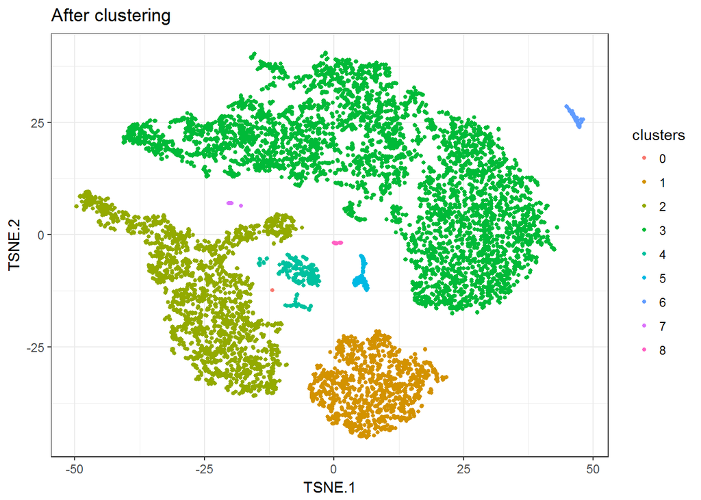

```r
creation_of_clusters <- dbscan(rna_experiment[2:3], eps = 3)

rna_experiment$clusters <- as.factor(creation_of_clusters$cluster)

ggplot(rna_experiment, aes(TSNE.1, TSNE.2, colour = clusters)) +
  ggtitle("After clustering") +
  theme_bw() +
  geom_point(size = 1)
```

```r
#радиус окружности (eps) = 3
#количество соседей (minPts) = 5 (Default)
```